# Project3

Can Wang

2024-10-11

## Data

```r
library("here")
rds_files <- c("b_lyrics.RDS", "ts_lyrics.RDS", "sales.RDS")
## Check whether we have all 3 files
if (any(!file.exists(here("data", rds_files)))) {
    ## If we don't, then download the data
    b_lyrics <- readr::read_csv("https://raw.githubusercontent.com/rfordatascience/tidytuesday/master/data/2020/2020-09-29/beyonce_lyrics.csv")
    ts_lyrics <- readr::read_csv("https://raw.githubusercontent.com/rfordatascience/tidytuesday/master/data/2020/2020-09-29/taylor_swift_lyrics.csv")
    sales <- readr::read_csv("https://raw.githubusercontent.com/rfordatascience/tidytuesday/master/data/2020/2020-09-29/sales.csv")

    ## Then save the data objects to RDS files
    saveRDS(b_lyrics, file = here("data", "b_lyrics.RDS"))
    saveRDS(ts_lyrics, file = here("data", "ts_lyrics.RDS"))
    saveRDS(sales, file = here("data", "sales.RDS"))
}
b_lyrics <- readRDS(here("data", "b_lyrics.RDS"))
ts_lyrics <- readRDS(here("data", "ts_lyrics.RDS"))
sales <- readRDS(here("data", "sales.RDS"))
```

## Part 1: Explore album sales

### Part 1A

1. Use lubridate to create a column called released that is a Date class. However, to be able to do this, you first need to use stringr to search for pattern that matches things like this “(US)[51]” in a string like this “September 1, 2006 (US)[51]” and removes them.

```r
library(dplyr)
library(stringr)
library(lubridate)
sales_1A <- sales %>%
  mutate(released_cleaned = str_remove(released, "\\s*\\(\\w{2}\\)\\[\\d+\\]$"))

sales_1A <- sales_1A %>%
  mutate(released_date = mdy(released_cleaned)) %>%
  select(-released, -released_cleaned) %>%  # Remove the original and cleaned columns
  rename(released = released_date)

sales_1A
```

```
## # A tibble: 48 × 8
##    artist       title        country   sales re_release label formats released
##    <chr>        <chr>        <chr>     <dbl> <chr>      <chr> <chr>   <date>
##  1 Taylor Swift Taylor Swift US       5.72e6 March 18,… Big … CD, CD… 2006-10-24
##  2 Taylor Swift Fearless     WW       1.20e7 October 2… Big … CD, CD… 2008-11-11
##  3 Taylor Swift Fearless     US       7.18e6 October 2… Big … CD, CD… 2008-11-11
##  4 Taylor Swift Fearless     AUS      5   e5 October 2… Big … CD, CD… 2008-11-11
##  5 Taylor Swift Fearless     UK       6.09e5 October 2… Big … CD, CD… 2008-11-11
##  6 Taylor Swift Speak Now    WW       5   e6 <NA>       Big … CD, CD… 2010-10-25
##  7 Taylor Swift Speak Now    US       4.69e6 <NA>       Big … CD, CD… 2010-10-25
##  8 Taylor Swift Speak Now    UK       1.69e5 <NA>       Big … CD, CD… 2010-10-25
##  9 Taylor Swift Red          WW       6   e6 <NA>       Big … CD, CD… 2012-10-22
## 10 Taylor Swift Red          US       4.47e6 <NA>       Big … CD, CD… 2012-10-22
## # ℹ 38 more rows
```

2. Use forcats to create a factor called country (Note: you may need to collapse some factor levels).

```r
unique(sales_1A$country)
```

```
##  [1] "US"    "WW"    "AUS"   "UK"    "JPN"   "CAN"   "FRA"   NA      "World"
## [10] "FR"
```

```r
library(forcats)

sales_1A2 <- sales_1A %>%
  mutate(country = as_factor(country))

sales_1A2 <- sales_1A2 %>%
  mutate(country = fct_recode(country,
                               "WW" = "World",
                               "FRA" = "FR"))
unique(sales_1A2$country)
```

```
## [1] US   WW   AUS  UK   JPN  CAN  FRA  <NA>
## Levels: US WW AUS UK JPN CAN FRA
```

3. Transform the sales into a unit that is album sales in millions of dollars.

```r
sales_1A3 <- sales_1A2 %>%
  mutate(sales_millions = sales / 1e6)  %>%
  select(-sales) %>%
  rename(sales = sales_millions)

print(sales_1A3)
```

```
## # A tibble: 48 × 8
##    artist       title        country re_release  label formats released    sales
##    <chr>        <chr>        <fct>   <chr>       <chr> <chr>   <date>      <dbl>
##  1 Taylor Swift Taylor Swift US      March 18, … Big … CD, CD… 2006-10-24  5.72
##  2 Taylor Swift Fearless     WW      October 27… Big … CD, CD… 2008-11-11 12
##  3 Taylor Swift Fearless     US      October 27… Big … CD, CD… 2008-11-11  7.18
##  4 Taylor Swift Fearless     AUS     October 27… Big … CD, CD… 2008-11-11  0.5
##  5 Taylor Swift Fearless     UK      October 27… Big … CD, CD… 2008-11-11  0.609
##  6 Taylor Swift Speak Now    WW      <NA>        Big … CD, CD… 2010-10-25  5
##  7 Taylor Swift Speak Now    US      <NA>        Big … CD, CD… 2010-10-25  4.69
##  8 Taylor Swift Speak Now    UK      <NA>        Big … CD, CD… 2010-10-25  0.169
##  9 Taylor Swift Red          WW      <NA>        Big … CD, CD… 2012-10-22  6
## 10 Taylor Swift Red          US      <NA>        Big … CD, CD… 2012-10-22  4.46
## # ℹ 38 more rows
```

4. Keep only album sales from the UK, the US or the World.

```r
sales_1A4 <- sales_1A3 %>%
  filter(country %in% c("UK", "US", "WW"))
```

5. Auto print your final wrangled tibble data frame.

```r
sales_1A4
```

```
## # A tibble: 36 × 8
##    artist       title        country re_release  label formats released    sales
##    <chr>        <chr>        <fct>   <chr>       <chr> <chr>   <date>      <dbl>
##  1 Taylor Swift Taylor Swift US      March 18, … Big … CD, CD… 2006-10-24  5.72
##  2 Taylor Swift Fearless     WW      October 27… Big … CD, CD… 2008-11-11 12
##  3 Taylor Swift Fearless     US      October 27… Big … CD, CD… 2008-11-11  7.18
##  4 Taylor Swift Fearless     UK      October 27… Big … CD, CD… 2008-11-11  0.609
##  5 Taylor Swift Speak Now    WW      <NA>        Big … CD, CD… 2010-10-25  5
##  6 Taylor Swift Speak Now    US      <NA>        Big … CD, CD… 2010-10-25  4.69
##  7 Taylor Swift Speak Now    UK      <NA>        Big … CD, CD… 2010-10-25  0.169
##  8 Taylor Swift Red          WW      <NA>        Big … CD, CD… 2012-10-22  6
##  9 Taylor Swift Red          US      <NA>        Big … CD, CD… 2012-10-22  4.46
## 10 Taylor Swift Red          UK      <NA>        Big … CD, CD… 2012-10-22  0.693
## # ℹ 26 more rows
```

### Part 1B

1. Keep only album sales from the US.

```r
sales_1B <- sales_1A4 %>%
  filter(country =='US')
sales_1B
```

```
## # A tibble: 13 × 8
##    artist       title          country re_release label formats released   sales
##    <chr>        <chr>          <fct>   <chr>      <chr> <chr>   <date>     <dbl>
##  1 Taylor Swift Taylor Swift   US      March 18,… Big … CD, CD… 2006-10-24  5.72
##  2 Taylor Swift Fearless       US      October 2… Big … CD, CD… 2008-11-11  7.18
##  3 Taylor Swift Speak Now      US      <NA>       Big … CD, CD… 2010-10-25  4.69
##  4 Taylor Swift Red            US      <NA>       Big … CD, CD… 2012-10-22  4.46
##  5 Taylor Swift 1989           US      <NA>       Big … CD, CD… 2014-10-27  6.22
##  6 Taylor Swift Reputation     US      <NA>       Big … CD, CD… 2017-11-10  2.3
##  7 Taylor Swift Lover          US      <NA>       Repu… CD, LP… 2019-08-23  1.08
##  8 Beyoncé      Dangerously i… US      <NA>       Colu… CD, LP… 2003-06-23  5.1
##  9 Beyoncé      B'Day          US      <NA>       Sony… CD, CD… 2006-09-01  3.61
## 10 Beyoncé      I Am... Sasha… US      <NA>       Musi… CD, CD… 2008-11-14  3.38
## 11 Beyoncé      4              US      <NA>       Park… CD, di… 2011-06-24  1.5
## 12 Beyoncé      Beyoncé        US      <NA>       Park… CD, CD… 2013-12-13  2.51
## 13 Beyoncé      Lemonade       US      <NA>       Park… CD/DVD… 2016-04-23  1.55
```

2. Create a new column called years_since_release corresponding to the number of years since the release of each album from Beyoncé and Taylor Swift. This should be a whole number and you should round down to “14” if you get a non-whole number like “14.12” years. (Hint: you may find the interval() function from lubridate helpful here, but this not the only way to do this.)

```r
sales_1B2 <- sales_1B %>%
  mutate(years_since_release = floor(as.numeric(interval(released, today())) /(365.25 * 24 * 60 * 60)))
sales_1B2
```

```
## # A tibble: 13 × 9
##    artist       title          country re_release label formats released   sales
##    <chr>        <chr>          <fct>   <chr>      <chr> <chr>   <date>     <dbl>
##  1 Taylor Swift Taylor Swift   US      March 18,… Big … CD, CD… 2006-10-24  5.72
##  2 Taylor Swift Fearless       US      October 2… Big … CD, CD… 2008-11-11  7.18
##  3 Taylor Swift Speak Now      US      <NA>       Big … CD, CD… 2010-10-25  4.69
##  4 Taylor Swift Red            US      <NA>       Big … CD, CD… 2012-10-22  4.46
##  5 Taylor Swift 1989           US      <NA>       Big … CD, CD… 2014-10-27  6.22
##  6 Taylor Swift Reputation     US      <NA>       Big … CD, CD… 2017-11-10  2.3
##  7 Taylor Swift Lover          US      <NA>       Repu… CD, LP… 2019-08-23  1.08
##  8 Beyoncé      Dangerously i… US      <NA>       Colu… CD, LP… 2003-06-23  5.1
##  9 Beyoncé      B'Day          US      <NA>       Sony… CD, CD… 2006-09-01  3.61
## 10 Beyoncé      I Am... Sasha… US      <NA>       Musi… CD, CD… 2008-11-14  3.38
## 11 Beyoncé      4              US      <NA>       Park… CD, di… 2011-06-24  1.5
## 12 Beyoncé      Beyoncé        US      <NA>       Park… CD, CD… 2013-12-13  2.51
## 13 Beyoncé      Lemonade       US      <NA>       Park… CD/DVD… 2016-04-23  1.55
## # ℹ 1 more variable: years_since_release <dbl>
```

3. Calculate the most recent, oldest, and the median years since albums were released for both Beyoncé and Taylor Swift.

```r
results <- sales_1B2 %>%
  group_by(artist) %>%
  summarise(
    most_recent = max(years_since_release),
    oldest = min(years_since_release),
    median = median(years_since_release)
  )
results
```

```
## # A tibble: 2 × 4
##   artist       most_recent oldest median
##   <chr>              <dbl>  <dbl>  <dbl>
## 1 Beyoncé               21      8     14
## 2 Taylor Swift          17      5     11
```

### Part 1C

1. Calculate the total album sales for each artist and for each country (only sales from the UK, US, and World).

```r
sales_1C <- sales_1A4 %>%
  group_by(artist,country) %>%
  summarise(total_sales=sum(sales))
sales_1C
```

```
## # A tibble: 6 × 3
## # Groups:   artist [2]
##   artist       country total_sales
##   <chr>        <fct>         <dbl>
## 1 Beyoncé      US            17.7
## 2 Beyoncé      WW            34.5
## 3 Beyoncé      UK             5.24
## 4 Taylor Swift US            31.7
## 5 Taylor Swift WW            40.8
## 6 Taylor Swift UK             3.32
```

2. Using the total album sales, create a percent stacked barchart using ggplot2 of the percentage of sales of studio albums (in millions) along the y-axis for the two artists along the x-axis colored by the country.

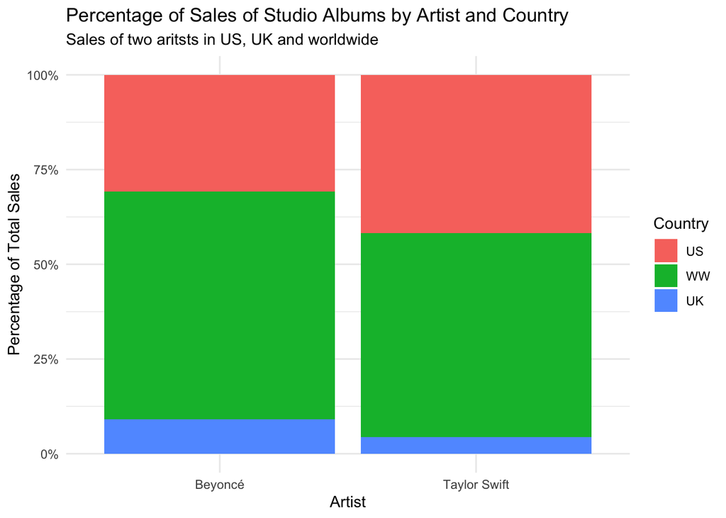

```r
library(ggplot2)
sales_percent <- sales_1C %>%
  group_by(artist, country) %>%
  summarise(total_sales = sum(total_sales, na.rm = TRUE)) %>%
  ungroup() %>%
  mutate(percentage = total_sales / sum(total_sales) * 100)
ggplot(sales_percent, aes(x = artist, y = percentage, fill = country)) +
  geom_bar(stat = "identity", position = "fill") +
  scale_y_continuous(labels = scales::percent_format()) +
  labs(title = "Percentage of Sales of Studio Albums by Artist and Country",
       subtitle = "Sales of two aritsts in US, UK and worldwide",
       x = "Artist",
       y = "Percentage of Total Sales",
       fill = "Country") +
  theme_minimal()
```

### Part 1D

Using the wrangled data from Part 1A, use ggplot2 to create a bar plot for the sales of studio albums (in millions) along the x-axis for each of the album titles along the y-axis.

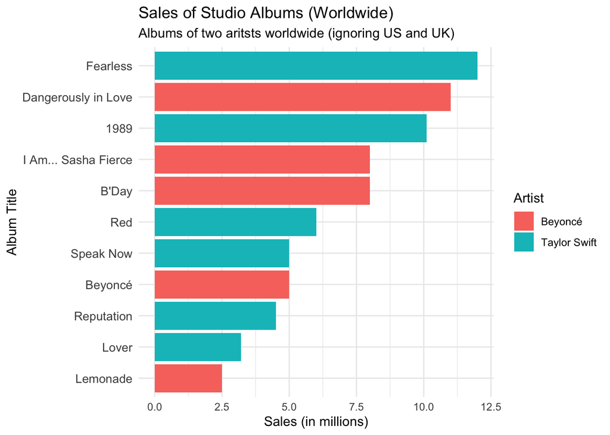

```r
library(forcats)

sales_ww <- sales_1A4 %>%
  filter(country == "WW")

ggplot(sales_ww, aes(x = fct_reorder(title, sales), y = sales, fill = artist)) +
  geom_bar(stat = "identity") +
  coord_flip() +
  labs(
    title = "Sales of Studio Albums (Worldwide)",
    subtitle = "Albums of two aritsts worldwide (ignoring US and UK)",
    x = "Album Title",
    y = "Sales (in millions)",
    fill = "Artist"
  ) +
  theme_minimal() +
  theme(axis.text.y = element_text(size = 10))
```

### Part 1E

Using the wrangled data from Part 1A, use ggplot2 to create a scatter plot of sales of studio albums (in millions) along the y-axis by the released date for each album along the x-axis.

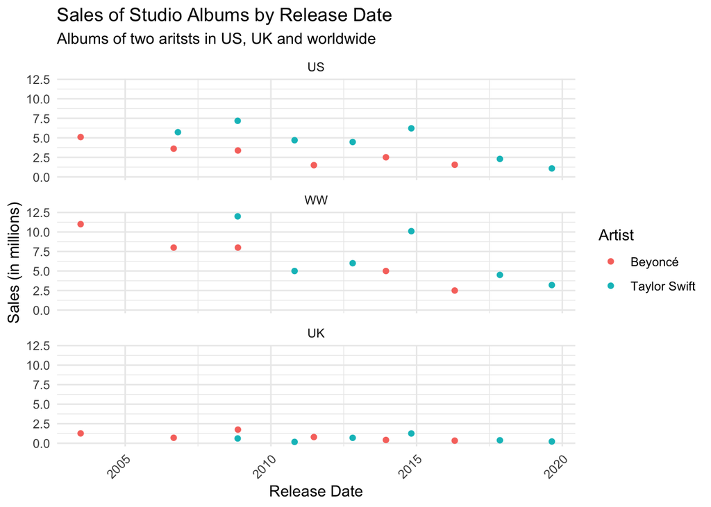

```r
ggplot(sales_1A4, aes(x = released, y = sales, color = artist)) +
  geom_point() +
  facet_wrap(~ country, nrow = 3) +
  labs(
    title = "Sales of Studio Albums by Release Date",
    subtitle = "Albums of two aritsts in US, UK and worldwide",
    x = "Release Date",
    y = "Sales (in millions)",
    color = "Artist"
  ) +
  theme_minimal() +
  theme(axis.text.x = element_text(angle = 45, hjust = 1))
```

## Part 2: Exploring sentiment of lyrics

### Part 2A

Using ts_lyrics, create a new column called line with one line containing the character string for each line of Taylor Swift’s songs.How many lines in Taylor Swift’s lyrics contain the word “hello”? For full credit, show all the rows in ts_lyrics that have “hello” in the line column and report how many rows there are in total.

```r
library(dplyr)
library(tidyr)
library(stringr)
ts_lyrics_2A <- ts_lyrics %>%
  mutate(line = strsplit(Lyrics, "\n")) %>%
  unnest(line)

part2a1 <- ts_lyrics_2A %>%
  filter(str_detect(line, regex("\\bhello\\b", ignore_case = TRUE)))
part2a1
```

```
## # A tibble: 6 × 5
##   Artist       Album    Title                  Lyrics                      line
##   <chr>        <chr>    <chr>                  <chr>                       <chr>
## 1 Taylor Swift Fearless Love Story             "We were both young when I… "And…
## 2 Taylor Swift Red      I Almost Do            "I bet\nThis time of night… "Tha…
## 3 Taylor Swift Red      Everything Has Changed "All I knew\nThis morning … "'Ca…
## 4 Taylor Swift Red      Everything Has Changed "All I knew\nThis morning … "'Ca…
## 5 Taylor Swift Red      Everything Has Changed "All I knew\nThis morning … "All…
## 6 Taylor Swift Red      Everything Has Changed "All I knew\nThis morning … "All…
```

```r
num_lines1 <- part2a1 %>% nrow()
num_lines1
```

```
## [1] 6
```

How many lines in Taylor Swift’s lyrics contain the word “goodbye”? For full credit, show all the rows in ts_lyrics that have “goodbye” in the line column and report how many rows there are in total.

```r
part2a2 <- ts_lyrics_2A %>%
  filter(str_detect(line, regex("\\bgoodbye\\b", ignore_case = TRUE)))
part2a2
```

```
## # A tibble: 12 × 5
##    Artist       Album        Title                      Lyrics             line
##    <chr>        <chr>        <chr>                      <chr>              <chr>
##  1 Taylor Swift Taylor Swift Tied Together With A Smile "Seems the only o… "Goo…
##  2 Taylor Swift Speak Now    Mine                       "Oh, oh, oh\nOh, … "Bra…
##  3 Taylor Swift Speak Now    Back to December           "I'm so glad you … "You…
##  4 Taylor Swift Speak Now    Long Live                  "I said remember … "And…
##  5 Taylor Swift Red          I Almost Do                "I bet\nThis time… "And…
##  6 Taylor Swift Red          Come Back Be Here          "You said it in a… "Stu…
##  7 Taylor Swift 1989         All You Had to Do Was Stay "People like you … "But…
##  8 Taylor Swift reputation   Getaway Car                "He was the best … "Sai…
##  9 Taylor Swift reputation   Getaway Car                "He was the best … "Sai…
## 10 Taylor Swift Lover        Death By A Thousand Cuts   "My, my, my, my\n… "Say…
## 11 Taylor Swift Lover        Death By A Thousand Cuts   "My, my, my, my\n… "'Ca…
## 12 Taylor Swift Lover        Daylight                   "My love was as c… "I'l…
```

```r
num_lines2 <- part2a2 %>% nrow()
num_lines2
```

```
## [1] 12
```

### Part 2B

Repeat the same analysis for b_lyrics as described in Part 2A.

```r
part2b1 <- b_lyrics %>%
  filter(str_detect(line, regex("\\bhello\\b", ignore_case = TRUE)))
part2b1
```

```
## # A tibble: 91 × 6
##    line                        song_id song_name artist_id artist_name song_line
##    <chr>                         <dbl> <chr>         <dbl> <chr>           <dbl>
##  1 Hello world, well I just b… 2220711 "Dreamgi…       498 Beyoncé             5
##  2 Hello Stevie, How you feel… 1981227 "Fingert…       498 Beyoncé             6
##  3 Fellow great Americans, he… 2715227 "FREEDOM…       498 Beyoncé            52
##  4 You had me at hello (Hello)   80249 "Hello"         498 Beyoncé            15
##  5 Hello (Hello)                 80249 "Hello"         498 Beyoncé            16
##  6 Hello (Hello)                 80249 "Hello"         498 Beyoncé            17
##  7 You had me at hello (Hello)   80249 "Hello"         498 Beyoncé            18
##  8 Hello (Hello)                 80249 "Hello"         498 Beyoncé            19
##  9 Hello (Hello)                 80249 "Hello"         498 Beyoncé            20
## 10 'Cause you had me at hello…   80249 "Hello"         498 Beyoncé            24
## # ℹ 81 more rows
```

```r
num_lines1 <- part2b1 %>% nrow()
num_lines1
```

```
## [1] 91
```

```r
part2b2 <- b_lyrics %>%
  filter(str_detect(line, regex("\\bgoodbye\\b", ignore_case = TRUE)))
part2b2
```

```
## # A tibble: 12 × 6
##    line                        song_id song_name artist_id artist_name song_line
##    <chr>                         <dbl> <chr>         <dbl> <chr>           <dbl>
##  1 We only said goodbye with …  139043 Back to …       498 Beyoncé            12
##  2 We only said goodbye with …  139043 Back to …       498 Beyoncé            21
##  3 We only said goodbye with …  139043 Back to …       498 Beyoncé            24
##  4 Thank God, I found the goo…   51492 Best Thi…       498 Beyoncé            38
##  5 Thank God, I found the goo… 1946060 Best Thi…       498 Beyoncé            42
##  6 Thank God, I found the goo… 4241137 Best Thi…       498 Beyoncé            38
##  7 It's so hard to say goodbye  435491 Gift fro…       498 Beyoncé            23
##  8 I never want to say goodbye  435491 Gift fro…       498 Beyoncé            24
##  9 I never, ever want to say …  435491 Gift fro…       498 Beyoncé            25
## 10 We've got to say goodbye    1844620 Hard To …       498 Beyoncé            29
## 11 Don't have to say goodbye   1224115 Slow Love       498 Beyoncé            42
## 12 Somewhere between hi and g…  141848 Yes             498 Beyoncé            27
```

```r
num_lines2 <- part2b2 %>% nrow()
num_lines2
```

```
## [1] 12
```

### Part 2C

```r
library(tidyverse)
```

```r
library(stringr)
library(tidytext)
library(janeaustenr)
library(tidytext)
library(dplyr)
library(wordcloud)
library(RColorBrewer)
lexicon <- get_sentiments("bing")
part2c <- b_lyrics
data(stop_words)
table(stop_words$lexicon)
```

```
##
##     onix    SMART snowball
##      404      571      174
```

```r
stop_words %>%
    head(n = 10)
```

```
## # A tibble: 10 × 2
##    word        lexicon
##    <chr>       <chr>
##  1 a           SMART
##  2 a's         SMART
##  3 able        SMART
##  4 about       SMART
##  5 above       SMART
##  6 according   SMART
##  7 accordingly SMART
##  8 across      SMART
##  9 actually    SMART
## 10 after       SMART
```

```r
part2c <- part2c %>%
  unnest_tokens(
        output = word,
        input = line,
        token = "words"
  ) %>% # Tokenize each lyrical line by words.
  anti_join(stop_words) %>% # 2. Remove the “stopwords”.
  count(word, sort = TRUE) # 3. Calculate the total number for each word in the lyrics.
part2c
```

```
## # A tibble: 5,937 × 2
##    word      n
##    <chr> <int>
##  1 love   1362
##  2 baby   1024
##  3 girl    592
##  4 wanna   564
##  5 hey     499
##  6 boy     494
##  7 yeah    491
##  8 feel    488
##  9 time    452
## 10 uh      408
## # ℹ 5,927 more rows
```

```r
part2c_4 <- part2c %>%
  inner_join(lexicon, by = "word") %>%  # 4. Using the “bing” sentiment lexicon, add a column to the summarized data frame adding the “bing” sentiment lexicon.
  arrange(desc(n)) %>%  # 5. Sort the rows from most frequent to least frequent words.
  slice_max(n, n = 25)  # 6. Only keep the top 25 most frequent words.
print(part2c_4) # 7. Auto print the wrangled tibble data frame.
```

```
## # A tibble: 25 × 3
##    word          n sentiment
##    <chr>     <int> <chr>
##  1 love       1362 positive
##  2 crazy       308 negative
##  3 top         241 positive
##  4 bad         132 negative
##  5 beautiful   131 positive
##  6 whoa        121 positive
##  7 damn        106 negative
##  8 hurt         90 negative
##  9 hard         87 negative
## 10 ready        85 positive
## # ℹ 15 more rows
```

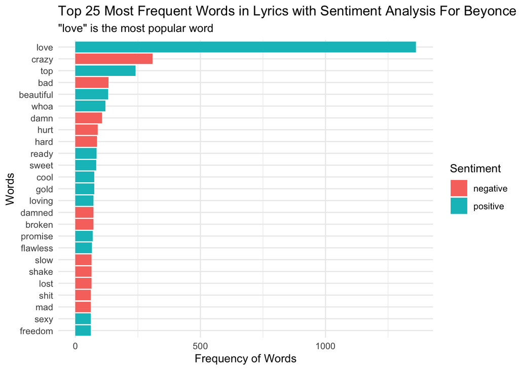

```r
part2c_4 <- part2c_4 %>%
  mutate(word = fct_reorder(word, n))

# 8. Use ggplot2 to create a bar plot with the top words on the y-axis and the frequency of each word on the x-axis. Color each bar by the sentiment of each word from the “bing” sentiment lexicon. Bars should be ordered from most frequent on the top to least frequent on the bottom of the plot.
ggplot(data = part2c_4, aes(x = n, y = word, fill = sentiment)) +
  geom_bar(stat = "identity") +
  labs(
    title = "Top 25 Most Frequent Words in Lyrics with Sentiment Analysis For Beyonce",
    subtitle = "\"love\" is the most popular word",
    x = "Frequency of Words",
    y = "Words",
    fill = "Sentiment"
  ) +
  theme_minimal()
```

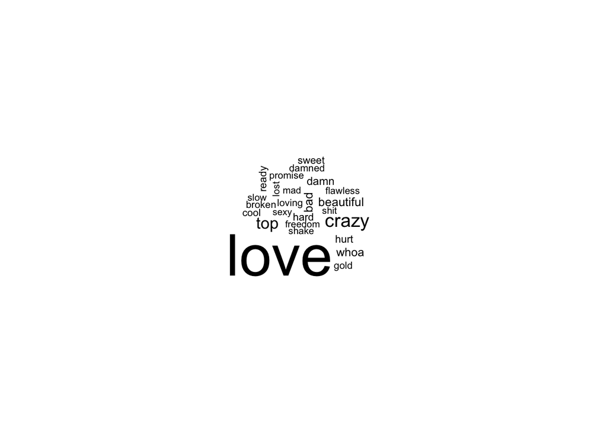

```r
part2c_4 %>%
  with(wordcloud(word, n, max.words = 25)) # 9. Create a word cloud of the top 25 most frequent words.
```

### Part 2D

```r
lexicon <- get_sentiments("bing")
part2d <- ts_lyrics_2A
data(stop_words)
table(stop_words$lexicon)
```

```
##
##     onix    SMART snowball
##      404      571      174
```

```r
stop_words %>%
    head(n = 10)
```

```
## # A tibble: 10 × 2
##    word        lexicon
##    <chr>       <chr>
##  1 a           SMART
##  2 a's         SMART
##  3 able        SMART
##  4 about       SMART
##  5 above       SMART
##  6 according   SMART
##  7 accordingly SMART
##  8 across      SMART
##  9 actually    SMART
## 10 after       SMART
```

```r
part2d <- part2d %>%
  unnest_tokens(
        output = word,
        input = line,
        token = "words"
  ) %>%
  count(word, sort = TRUE)
part2d
```

```
## # A tibble: 3,022 × 2
##    word      n
##    <chr> <int>
##  1 i      2392
##  2 you    2319
##  3 the    1623
##  4 and    1405
##  5 me      892
##  6 to      844
##  7 a       788
##  8 in      686
##  9 it      674
## 10 my      642
## # ℹ 3,012 more rows
```

```r
part2d_4 <- part2d %>%
  inner_join(lexicon, by = "word") %>%
  arrange(desc(n)) %>%
  slice_max(n, n = 25)

print(part2d_4)
```

```
## # A tibble: 26 × 3
##    word       n sentiment
##    <chr>  <int> <chr>
##  1 like     406 positive
##  2 love     248 positive
##  3 right    110 positive
##  4 bad       80 negative
##  5 good      76 positive
##  6 better    74 positive
##  7 shake     73 negative
##  8 break     59 negative
##  9 best      52 positive
## 10 mad       48 negative
## # ℹ 16 more rows
```

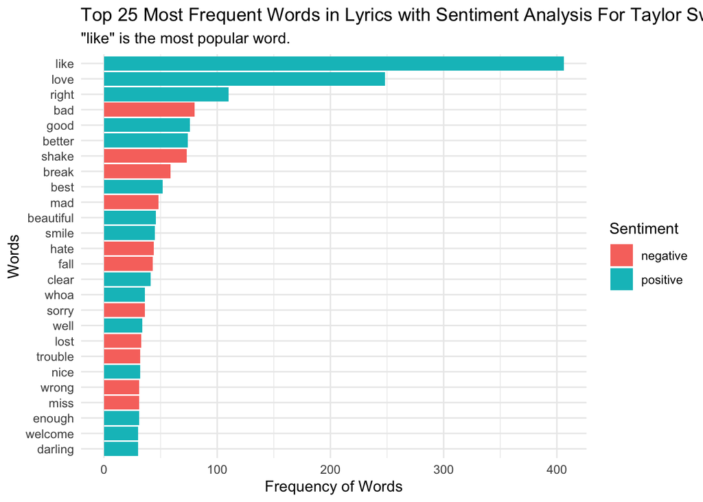

```r
part2d_4 <- part2d_4 %>%
  mutate(word = fct_reorder(word, n))

ggplot(data = part2d_4, aes(x = n, y = word, fill = sentiment)) +
  geom_bar(stat = "identity") +
  labs(
    title = "Top 25 Most Frequent Words in Lyrics with Sentiment Analysis For Taylor Swift",
    subtitle = "\"like\" is the most popular word.",
    x = "Frequency of Words",
    y = "Words",
    fill = "Sentiment"
  ) +
  theme_minimal()
```

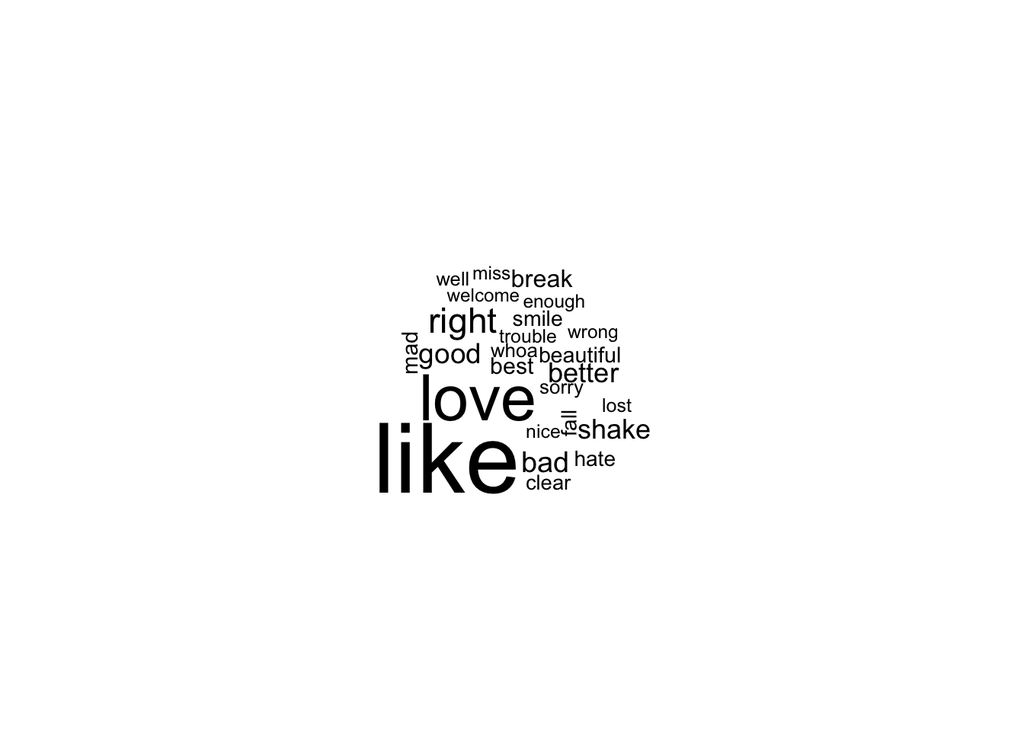

```r
part2d_4 %>%
  with(wordcloud(word, n, max.words = 25))
```

### Part2E

```r
library(textdata)
lexicon <- get_sentiments("afinn")

part2e <- ts_lyrics_2A
data(stop_words)
table(stop_words$lexicon)
```

```
##
##     onix    SMART snowball
##      404      571      174
```

```r
stop_words %>%
    head(n = 10)
```

```
## # A tibble: 10 × 2
##    word        lexicon
##    <chr>       <chr>
##  1 a           SMART
##  2 a's         SMART
##  3 able        SMART
##  4 about       SMART
##  5 above       SMART
##  6 according   SMART
##  7 accordingly SMART
##  8 across      SMART
##  9 actually    SMART
## 10 after       SMART
```

```r
part2e <- part2e %>%
  unnest_tokens(
        output = word,
        input = line,
        token = "words"
  ) %>% # 1. Tokenize each lyrical line by words.
  anti_join(stop_words) %>% # 2. Remove the “stopwords”.
  group_by(Album) %>%
  count(word, sort = TRUE) # 3. Calculate the total number for each word in the lyrics for each Album.
part2e
```

```
## # A tibble: 4,968 × 3
## # Groups:   Album [8]
##    Album word         n
##    <chr> <chr>    <int>
##  1 1989  love        82
##  2 1989  shake       70
##  3 Red   time        66
##  4 Lover ooh         61
##  5 Red   uh          50
##  6 Red   red         46
##  7 Lover love        44
##  8 Lover wanna       42
##  9 1989  baby        41
## 10 Lover daylight    40
## # ℹ 4,958 more rows
```

```r
part2e_4 <- part2e %>%
  inner_join(lexicon, by = "word") %>%  # 4. Using the “afinn” sentiment lexicon, add a column to the summarized data frame adding the “afinn” sentiment lexicon.
  group_by(Album) %>%
  summarise(average_sentiment_score = sum(value * n, na.rm = TRUE) / sum(n, na.rm = TRUE)) # 5. Calculate the average sentiment score for each Album.

print(part2e_4) # 6. Auto print the wrangled tibble data frame.
```

```
## # A tibble: 8 × 2
##   Album        average_sentiment_score
##   <chr>                          <dbl>
## 1 1989                         -0.215
## 2 Fearless                      0.452
## 3 Lover                         0.0960
## 4 Red                           0.256
## 5 Speak Now                     0.0219
## 6 Taylor Swift                  0.646
## 7 folklore                     -0.396
## 8 reputation                    0.0501
```

[figure not shown]

```r
part2e_4 <- part2e_4 %>%
  mutate(Album = ifelse(Album == "reputation", "Reputation", Album))

part2e_1a <- sales_1A %>%
  filter(country =="US") %>%
  rename(Album = title)

part2e_joint <- inner_join(part2e_1a, part2e_4, by = "Album") # 7. Join the wrangled data frame from Part 1A (album sales in millions) filtered down to US sales with the wrangled data frame from #6 above (average sentiment score for each album).

# 8-9. Using ggplot2, create a scatter plot of the average sentiment score for each album (y-axis) and the album release data along the x-axis. Make the size of each point the album sales in millions. Add a horizontal line at y-intercept=0.
ggplot(part2e_joint, aes(x = released, y = average_sentiment_score, size = sales)) +
  geom_point(aes(color = Album)) +
  geom_hline(yintercept = 0) +
  labs(
    title = "Sentiment Analysis of Taylor Swift's Albums Over Time",
    subtitle = "Average Sentiment Scores and Album Sales in Millions",
    x = "Album Release Date",
    y = "Average Sentiment Score",
    size = "Album Sales (in Millions)",
    color = "Album"
  ) +
  theme_minimal()
```

10. Write 2-3 sentences interpreting the plot answering the question “How has the sentiment of Taylor Swift’s albums have changed over time?”

Interpretation: Generally, average sentiment score decreases over years in TS’s albums. Early albums (especially before 2010) has high sentiment scores(around 0.5). “1989” in about 2015 has a low sentiment score(less than zero). But her most recent albums have medium sentiment scores (slightly higher than 0).